# NumPy

Esta librería a diferencia de matlab/octave utiliza principalmente arreglos multidimensionales

Para importar librerías se realiza de 3 maneras

1) Importando la librería por su nombre

```python
import numpy
```

- Para llamar una función de esta manera se debe realizar lo sig.

```python
numpy.array([1, 2])
```

```
array([1, 2])
```

2) Importando una función específica o todas las funciones de la librería

```python
from numpy import array
```

```python
array([1 , 2])
```

```
array([1, 2])
```

```python
from numpy import *
```

```python
pi
```

```
3.141592653589793
```

```python
math.pi
```

```
3.141592653589793
```

```python
timeit pi
```

```
The slowest run took 88.68 times longer than the fastest. This could mean that an intermediate result is being cached
10000000 loops, best of 3: 45.7 ns per loop
```

```python
timeit math.pi
```

```
The slowest run took 36.23 times longer than the fastest. This could mean that an intermediate result is being cached
10000000 loops, best of 3: 138 ns per loop
```

3) Importando la librería con un alias

```python
import numpy as np
```

```python
np.array([[1,2],[3,4]])
```

```
array([[1, 2],
       [3, 4]])
```

# Pandas

Esta librería está construída en base a NumPy, para brindar eficiencia, y sirve para manejar tablas de datos en memoria ram y realizar diversos tipos de análisis.

Funciona muy bien para:

- Matrices
- Datos tabulares (se puede exportar datos csv, excel, etc)
- Series temporales (Manejo de fechas en los datos)

**Ejemplo de uso:**

Importamos la librería:

```python
import pandas as pd
```

Importamos datos de un archivo csv:

(Datos extraídos de Kaggle competition, una página con desafíos de aprendizaje automático, machine learning, consta de datos de bicicletas compartidas)

```python
datos = pd.read_csv('hour.csv', index_col=0)
```

```python
datos.head()
```

| instant | dteday | season | yr | mnth | hr | holiday | weekday | workingday | weathersit | temp | atemp | hum | windspeed | casual | registered | cnt |
| --- | --- | --- | --- | --- | --- | --- | --- | --- | --- | --- | --- | --- | --- | --- | --- | --- |
| 1 | 2011-01-01 | 1 | 0 | 1 | 0 | 0 | 6 | 0 | 1 | 0.24 | 0.2879 | 0.81 | 0 | 3 | 13 | 16 |
| 2 | 2011-01-01 | 1 | 0 | 1 | 1 | 0 | 6 | 0 | 1 | 0.22 | 0.2727 | 0.80 | 0 | 8 | 32 | 40 |
| 3 | 2011-01-01 | 1 | 0 | 1 | 2 | 0 | 6 | 0 | 1 | 0.22 | 0.2727 | 0.80 | 0 | 5 | 27 | 32 |
| 4 | 2011-01-01 | 1 | 0 | 1 | 3 | 0 | 6 | 0 | 1 | 0.24 | 0.2879 | 0.75 | 0 | 3 | 10 | 13 |
| 5 | 2011-01-01 | 1 | 0 | 1 | 4 | 0 | 6 | 0 | 1 | 0.24 | 0.2879 | 0.75 | 0 | 0 | 1 | 1 |

```python
len(datos)
```

```
17379
```

```python
datos.info()
```

```
<class 'pandas.core.frame.DataFrame'>
Int64Index: 17379 entries, 1 to 17379
Data columns (total 16 columns):
dteday        17379 non-null object
season        17379 non-null int64
yr            17379 non-null int64
mnth          17379 non-null int64
hr            17379 non-null int64
holiday       17379 non-null int64
weekday       17379 non-null int64
workingday    17379 non-null int64
weathersit    17379 non-null int64
temp          17379 non-null float64
atemp         17379 non-null float64
hum           17379 non-null float64
windspeed     17379 non-null float64
casual        17379 non-null int64
registered    17379 non-null int64
cnt           17379 non-null int64
dtypes: float64(4), int64(11), object(1)
memory usage: 2.3+ MB
```

```python
%matplotlib inline
```

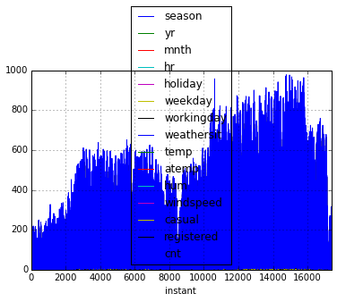

```python
datos.plot()
```

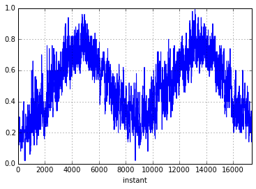

```python
plot1 = datos.temp.plot()
```

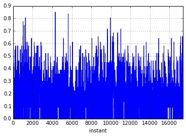

```python
datos.windspeed.plot()
```

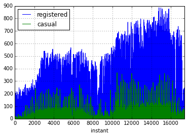

```python
datos[['registered','casual']].plot()
```

```python
datos.registered.describe()
```

```
count    17379.000000
mean       153.786869
std        151.357286
min          0.000000
25%         34.000000
50%        115.000000
75%        220.000000
max        886.000000
Name: registered, dtype: float64
```

```python
import mpld3
```

```python
mpld3.enable_notebook()
```

```python
datos[['casual','registered']].plot()
```

[output not shown]

```python
datos[['casual','registered']][0:1000].plot()
```

[output not shown]

```python
mpld3.disable_notebook()
```

Escribir matrices y leerlas con pandas (si la nomenclatura de numpy te parece muy tediosa)

```python
%%writefile matriz.csv
1 2 3 4 5 6 7 8 9 10
11 12 13 14 15 16 17 18 19 20
21 22 23 24 25 26 27 28 29 30
31 32 33 34 35 36 37 38 39 40
41 41 43 44 45 46 47 48 49 50
```

```
Overwriting matriz.csv
```

```python
matriz = pd.read_csv('matriz.csv', sep=' ', header=None)
```

```python
matriz
```

|  | 0 | 1 | 2 | 3 | 4 | 5 | 6 | 7 | 8 | 9 |
| --- | --- | --- | --- | --- | --- | --- | --- | --- | --- | --- |
| 0 | 1 | 2 | 3 | 4 | 5 | 6 | 7 | 8 | 9 | 10 |
| 1 | 11 | 12 | 13 | 14 | 15 | 16 | 17 | 18 | 19 | 20 |
| 2 | 21 | 22 | 23 | 24 | 25 | 26 | 27 | 28 | 29 | 30 |
| 3 | 31 | 32 | 33 | 34 | 35 | 36 | 37 | 38 | 39 | 40 |
| 4 | 41 | 41 | 43 | 44 | 45 | 46 | 47 | 48 | 49 | 50 |

```python
matriz.as_matrix()
```

```
array([[ 1,  2,  3,  4,  5,  6,  7,  8,  9, 10],
       [11, 12, 13, 14, 15, 16, 17, 18, 19, 20],
       [21, 22, 23, 24, 25, 26, 27, 28, 29, 30],
       [31, 32, 33, 34, 35, 36, 37, 38, 39, 40],
       [41, 41, 43, 44, 45, 46, 47, 48, 49, 50]])
```

```python
matriz.T
```

|  | 0 | 1 | 2 | 3 | 4 |
| --- | --- | --- | --- | --- | --- |
| 0 | 1 | 11 | 21 | 31 | 41 |
| 1 | 2 | 12 | 22 | 32 | 41 |
| 2 | 3 | 13 | 23 | 33 | 43 |
| 3 | 4 | 14 | 24 | 34 | 44 |
| 4 | 5 | 15 | 25 | 35 | 45 |
| 5 | 6 | 16 | 26 | 36 | 46 |
| 6 | 7 | 17 | 27 | 37 | 47 |
| 7 | 8 | 18 | 28 | 38 | 48 |
| 8 | 9 | 19 | 29 | 39 | 49 |
| 9 | 10 | 20 | 30 | 40 | 50 |

```python
matriz*matriz
```

|  | 0 | 1 | 2 | 3 | 4 | 5 | 6 | 7 | 8 | 9 |
| --- | --- | --- | --- | --- | --- | --- | --- | --- | --- | --- |
| 0 | 1 | 4 | 9 | 16 | 25 | 36 | 49 | 64 | 81 | 100 |
| 1 | 121 | 144 | 169 | 196 | 225 | 256 | 289 | 324 | 361 | 400 |
| 2 | 441 | 484 | 529 | 576 | 625 | 676 | 729 | 784 | 841 | 900 |
| 3 | 961 | 1024 | 1089 | 1156 | 1225 | 1296 | 1369 | 1444 | 1521 | 1600 |
| 4 | 1681 | 1681 | 1849 | 1936 | 2025 | 2116 | 2209 | 2304 | 2401 | 2500 |

```python
matriz.dot(matriz.T)
```

|  | 0 | 1 | 2 | 3 | 4 |
| --- | --- | --- | --- | --- | --- |
| 0 | 385 | 935 | 1485 | 2035 | 2583 |
| 1 | 935 | 2485 | 4035 | 5585 | 7123 |
| 2 | 1485 | 4035 | 6585 | 9135 | 11663 |
| 3 | 2035 | 5585 | 9135 | 12685 | 16203 |
| 4 | 2583 | 7123 | 11663 | 16203 | 20702 |

```python
from IPython.html.widgets import *
```

Podemos crear barras deslizables:

```python
barra = IntSlider()
```

```python
barra
```

```python
from IPython.display import display
```

```python
display(barra)
```

```python
barra.close()
```

```python
w = IntSlider()
```

```python
w
```

```python
w.value
```

```
82
```